# Lexical of 20th century Odyssey translations (Part A): Token Distribution

## **Road Map**

**I. Libraries, files, and paths**

**II. The Texts**

1. Bibliographic information about the translators
2. The translators at a glance tokenwise

**III. TTR Analysis**

1. All-in, straightforward model  
   a) TTR Computation  
   b) Shapiro-Wilk test to check for normality  
   c) One-wat ANOVA for overall differences  
   d) Pairwise t-test using Bonferroni coprrection  
   c) Meassuring effect size ussing Cohen's d
2. Adaptive models  
   a) Mixed-Effects model: author fixed effect / book as random effect  
   b) Standardized TTR:  
   c) Moving-average TTR: translation as temporal change
3. Supplement models  
   a) Lexical Density  
   b) Diachronic analysis  
   c) Semantic fields:

**IV. Zipf's Law**

**V. TF-IDF**

**VI. Discussing Results**

```python
import autotime # Provision for anxious people
%load_ext autotime
```

```
time: 67.3 μs (started: 2025-04-20 20:52:46 +02:00)
```

```python
# ----------------------------------------------------------------------
# Baic Libraries
# ----------------------------------------------------------------------

import sys
import os

import ast
from collections import Counter

import re
import nltk

import numpy as np
import pandas as pd

import pandas as pd
import statsmodels.formula.api as smf
import statsmodels.api as sm

import scipy.stats as stats
from itertools import combinations
```

```python
# ----------------------------------------------------------------------
# Personalized Visualization & Functions
# ----------------------------------------------------------------------

sys.path.append('/Users/debr/English-Homer/functions')
import matplotlib.pyplot as plt
import seaborn as sns
from matplotlib.colors import LinearSegmentedColormap

import e_chroma as chroma # My Vizualization library
import e_plots as oz      # My custom plots library
import e_pandisplay as pan# My pandas display options

import e_nlp_ody as e     # Import my nlp functions

import warnings           # Nononsense provision
warnings.filterwarnings('ignore')
```

```
* Got some chroma in your soma, Oma!
	 »----> use chroma.save_figure(fig, 'my_plot')
Default output path: ./Homer_xplots/

* OZ is behind the curtain!
	 »----> use oz.<func>
	 »----> also, oz goes chroma (for styling)!

*Has Pan taken over?
✓ Pandas display set to e_pandisplay defaults!
	 »----> use pan.<func>

* The editor is in the house!
	 »----> use e.<func> e.g. nlp = e.NLPPipeline(language='english')

Stopwords customized:
  Added: {'they', 'been', 'one', 'seven', 'mr', 'six', 'it', 'eight', 'this', 'upon', 'mrs', "'", 'he', 'five', 'them', 'three', "'and", 'there', 'were', 'that', 'of', 'was', 'being', 'two', 'is', 'are', 'said', 'four', 'she', 'ten', 'nine', 'n', 'be'}
  Removed: {''}
  Total stopwords: 215
Punctuation customized:
  Keeping: {'', '-'}
  Additional removals: {'-', '…', '—', '\\', "'", ',\n        "\'",\n        '}
  Punctuation to be removed: !"#$%&'()*+,,
        "'",
        -./:;<=>?@[\]^_`{|}~—…
```

```python
# ----------------------------------------------------------------------
# File management
# ----------------------------------------------------------------------

# TO UPDATE
nb_id = "lexical_A01"

output_path = f"./"
os.makedirs(os.path.dirname(output_path), exist_ok=True)
output_path_plots = f"./{output_path}/{nb_id}_plots/"
os.makedirs(os.path.dirname(output_path_plots), exist_ok=True)
chroma.set_output_path(output_path_plots)
```

```
Output path set to: ././/lexical_A01_plots/
time: 3.03 ms (started: 2025-04-20 20:52:49 +02:00)
```

```python
# ----------------------------------------------------------------------
# Odysseys
# ----------------------------------------------------------------------

translators = ['AT_Murray', 'Fitzgerald', 'Lattimore', 'Fagles', 'Wilson', 'Green', 'Woolf']

dfs = []

for odyssey in translators:
    filepath = f"/Users/debr/odysseys_en/dataframed/Odyssey_{odyssey}_DataFrame.csv"
    temp_df = pd.read_csv(filepath)
    dfs.append(temp_df)  # Append it to the list

df = pd.concat(dfs, axis=0, ignore_index=True)

df["text"] = df["text"].apply(ast.literal_eval)
df["tokens"] = df["tokens"].apply(ast.literal_eval)
df['translator'] = pd.Categorical(df['author'])
df["book_num"] = pd.Categorical(df["book_num"])
df = df[['translator', 'book_num', 'text', 'tokens', 'num_words', 'num_tokens']]
df["diff"] = df["num_words"] - df["num_tokens"]

# ----------------------------------------------------------------------
# Backup dataframe only 'translator', 'book_num', 'text', 'tokens', columns
# ----------------------------------------------------------------------
df_bkp = df[['translator', 'book_num', 'text', 'tokens']].copy()
# ----------------------------------------------------------------------
# Dataframe check
# ----------------------------------------------------------------------

e.check_df(df)
```

```
Mr righteous here has no missing values!

* df columns: Index(['translator', 'book_num', 'text', 'tokens', 'num_words', 'num_tokens', 'diff'], dtype='object')

* Shape: (168, 7)

* Total memory in MB: 4.066093
time: 696 ms (started: 2025-04-20 20:52:49 +02:00)
```

```python
df.sample(4, random_state=1001)
```

|  | translator | book_num | text | tokens | num_words | num_tokens | diff |
| --- | --- | --- | --- | --- | --- | --- | --- |
| 145 | Woolf | 2 | [Uncomfortable as the night, with its rocking movement, and salt smells,\n, may have been, and in one case undoubtedly was, for Mr. Pepper had\n, insufficient clothes upon his bed, the breakfast n... | [uncomfortable, night, rocking, movement, salt, smells, may, case, undoubtedly, mr, pepper, insufficient, clothes, upon, bed, breakfast, next, morning, wore, kind, beauty, voyage, begun, begun, ha... | 5430 | 2573 | 2857 |
| 117 | Wilson | 22 | [Odysseus ripped oﬀ his rags. Now naked,\n, he leapt upon the threshold with his bow\n, and quiverfull of arrows, which he tipped\n, out in a rush before his feet, and spoke.\n, “Playtime is over.... | [odysseus, ripped, oﬀ, rags, naked, leapt, upon, threshold, bow, quiverfull, arrows, tipped, rush, feet, spoke, playtime, shoot, towards, another, mark, man, hit, apollo, may, manage, aimed, deadl... | 4000 | 1959 | 2041 |
| 94 | Fagles | 23 | [Up to the rooms the old nurse clambered, chuckling all the way,\n, to tell the queen her husband was here now, home at last.\n, Her knees bustling, feet shuffling over each other,\n, till hoverin... | [rooms, old, nurse, clambered, chuckling, way, tell, queen, husband, home, last, knees, bustling, feet, shuffling, till, hovering, mistress, head, spoke, penelope, child, wake, see, eyes, dreamed,... | 3939 | 1900 | 2039 |
| 138 | Green | 19 | [So noble Odysseus was left behind, there in the hall,\n, with Athene’s aid contriving a plan to kill the suitors;\n, and now he addressed Telemachos with winged words, saying:\n, “Telemachos, we ... | [noble, odysseus, left, behind, hall, athene, aid, contriving, plan, kill, suitors, addressed, telemachos, winged, words, saying, telemachos, must, lay, weapons, war, inside, disarm, suitors, soot... | 6366 | 2942 | 3424 |

```
time: 47.3 ms (started: 2025-04-20 20:52:49 +02:00)
```

## **II. The Texts**

### **1. Bibliographic information about the translators**

Here is a brief description of each translation and the baseline. The publication period of the sample spans 100 years, from 1919 to 2018. Virginia Woolf's *The Voyage Out* is taken as a baseline because her prose mixes a high register with modern prose style––here it is assumed as a representative sample of the best prose in English.

| Author | Year | Period | Span | Verse | Publisher | Edition | Source | URL | Notes | Bibliography |
| --- | --- | --- | --- | --- | --- | --- | --- | --- | --- | --- |
| Augustus Taber Murray | 1919 | Modernism | 1910-1940 | FALSE | Harvard UP, Loeb | 1919 | Scaife Viewer, Tufts University | [Link](https://scaife.perseus.org/library/urn:cts:greekLit:tlg0012.tlg002/) | "No more faithful translation of Homer was ever made, and its elegance matched its fidelity. Homer's formulaic epithets, phrases, and sentences were consistently rendered, and his artificial amalgam o… | *Homer. The Odyssey, Vol. 1-2. Murray, A. T. (Augustus Taber), translator. London: William Heinmann; New York: G.P. Putnam's Sons, 1919.* |
| Robert Fitzgerald | 1961 | (Ur)Postmodernism | 1960-1979 | TRUE | Doubleday & Company, Inc. | Second 1963 Edition | Internet Archive | [Link](https://archive.org/details/homer-the-odyssey-800-bce-robert-fitzgerald-tr-1961) | "Written in very readable, American “plain style” language" (Carolyn Clark, Best American Poetry, 2020) | *Homer. The Odyssey. Fitzgerald, Robert, translator. New York: Doubleday & Company, Inc., 1961* |
| Richmond Lattimore | 1965 | (Ur)Postmodernism | 1960-1979 | TRUE | Farrar, Straus & Giroux | First 1965 Edition | Harper Collins E-Books | NONE | "Prose-like verse translation" (Carolyn Clark, Best American Poetry, 2020). | *Homer. The Odyssey. Lattimore, Richmond, translator. New York: Doubleday & Company, Inc., 1965* |
| Robert Fagles | 1996 | Postmodernism | 1980-1999 | TRUE | Penguin | First 1996 Edition | PDF SCAN | NONE | "Fagles awareness of Homer’s grace and ongkos (body? lumpiness, even!) is such that he gives us a plausible epic, persuasive, engaging, and resonant. He deserves congratulations and thanks" (Bryn Mawr… | *Homer. The Odyssey. Fagles, Robert, translator. University of California Press, 1996* |
| Emily Wilson | 2017 | Contemporary | >2000 | TRUE | W.W. Norton & Company Inc. | First 2017 Edition | PDF SCAN | NONE | "Emily Wilson’s crisp and musical version is a cultural landmark. Armed with a sharp, scholarly rigour, she has produced a translation that exposes centuries of masculinist readings of the poem" (Higg… | *Homer. The Odyssey. Wilson, Emily, translator. W.W. Norton & Company Inc., 2017* |
| Peter Green | 2018 | Contemporary | >2000 | TRUE | University of California Press | Digital | EBSCOhost | [Link](https://search.ebscohost.com/login.aspx?direct=true&scope=site&db=nlebk&db=nlabk&AN=1696363) | "Green’s Odyssey is unified by a flexible hexameter line … but it combines this unity with great variety of pace and tone, giving vivid but different expression to the contrasting elements that make t… | *Homer. The Odyssey. Green, Peter, translator. University of California Press, 2018* |
| Virginia Woolf | 1915 | Modernism | 1910-1940 | FALSE | Project Gutenberg eBook | 2024 [2006] | Project Gutenberg eBook | [Link](https://www.gutenberg.org/cache/epub/144/pg144.txt) | Baseline | Woolf, V. *The Voyage Out*. Duckworth, London, 1915 |

### Use of Latin vs Greek Forms for Characters' Names by Translator

There is an interesting inconsistency in how different translators handle character names in the Odyssey. Up until Fagles, every translator used a mix of direct Greek transliteration and conventional names passed down through earlier tradition.

- **Murray:** Tends to use Greek forms (Telemakhos, Menelaos) yet more popular names (Odysseus, Athena) remain in their Latin form.
- **Fitzgerald:** Opts for transliterating Greek phonetics, like Murray's "Telemakhos" but takes this approach further with forms like "Akhilleus." However, other names still retain their popular form.
- **Lattimore:** Uses fewer Greek forms than Fitzgerald (e.g., "Telemachus" rather than "Telemakhos") but still employs "Athene" and "Achilleus."
- **Fagles:** Experiments less with character names and settles on conventional forms that would be more familiar to modern readers.
- **Wilson:** Follows the same naming conventions as Fagles, prioritizing accessibility.
- **Green:** Returns to a Greek flavor by including Greek diacritical marks in names: Achillēs, Menelaös, Tēlemachos, Athēnē.

The names of places follow the same pattern across these translations. This naming variation will be analyzed thoroughly in the Named Entity Recognition step of the project, which will allow us to quantitatively compare these stylistic choices across the different translations.

### 2. **The translators at a glance**

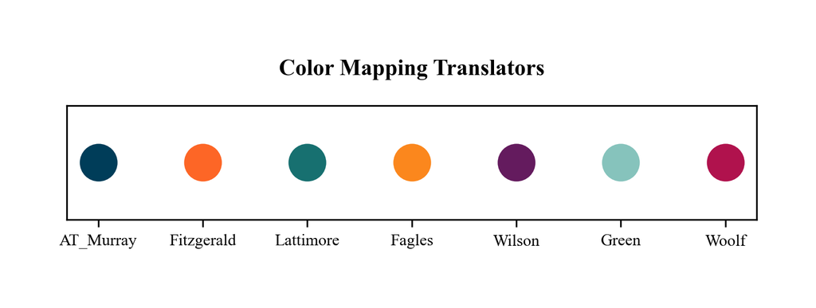

```
time: 145 ms (started: 2025-04-20 20:52:49 +02:00)
```

```python
# ----------------------------------------------------------------------
# Create a color mapping for translators
# ----------------------------------------------------------------------

translators = df["translator"].unique()
palette = {translator: color for translator,
           color in zip(translators, chroma.color_palette.values())}

plt.figure(figsize=(6, 1))

for i, (translator, color) in enumerate(palette.items()):
    plt.scatter(i, 0, color=color, s=300)

plt.xticks(range(len(palette)), palette.keys(), fontsize=8)
plt.yticks([])
plt.title("Color Mapping Translators", fontsize=11)
plt.savefig(f"{output_path_plots}translator_color_mapping-{nb_id}.png")
plt.show()
```

#### **a) Lenght and distribution**

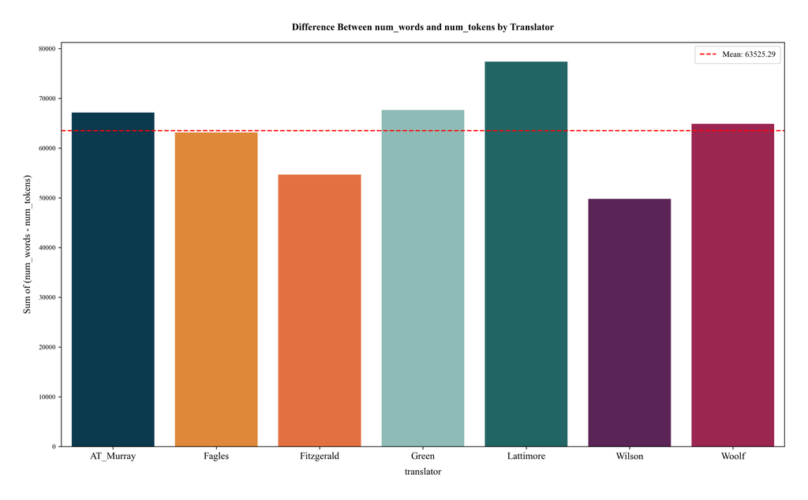

```
The most verbose translator is Lattimore with a difference of 77405
The most concise translator is Wilson with a difference of 49769
time: 651 ms (started: 2025-04-20 20:52:50 +02:00)
```

```python
# ----------------------------------------------------------------------
# Plot differences between num_words and num_tokens
# To visualize word-to-token ratio: verbose or concise
# ----------------------------------------------------------------------

# Aggregate sum per translator
agg_diff = df.groupby("translator")["diff"].sum()
mean_agg_diff = agg_diff.mean()

# Plot
sns.barplot(data=df, x="translator", y="diff", estimator=sum, errorbar=None,
            palette=palette)  # Explicit color mapping

# Mean horizontal line
plt.axhline(mean_agg_diff, color="red", linestyle="--",
            label=f"Mean: {mean_agg_diff:.2f}")

# Labels and title
plt.xlabel("translator")
plt.ylabel("Sum of (num_words - num_tokens)")
plt.title("Difference Between num_words and num_tokens by Translator")
plt.legend()
plt.savefig(output_path_plots + f"diff_words_tokens-{nb_id}.png")  # Save plot
plt.show()
# ----------------------------------------------------------------------
print(f"The most verbose translator is {agg_diff.idxmax()} with a difference of {agg_diff.max()}")
print(f"The most concise translator is {agg_diff.idxmin()} with a difference of {agg_diff.min()}")
```

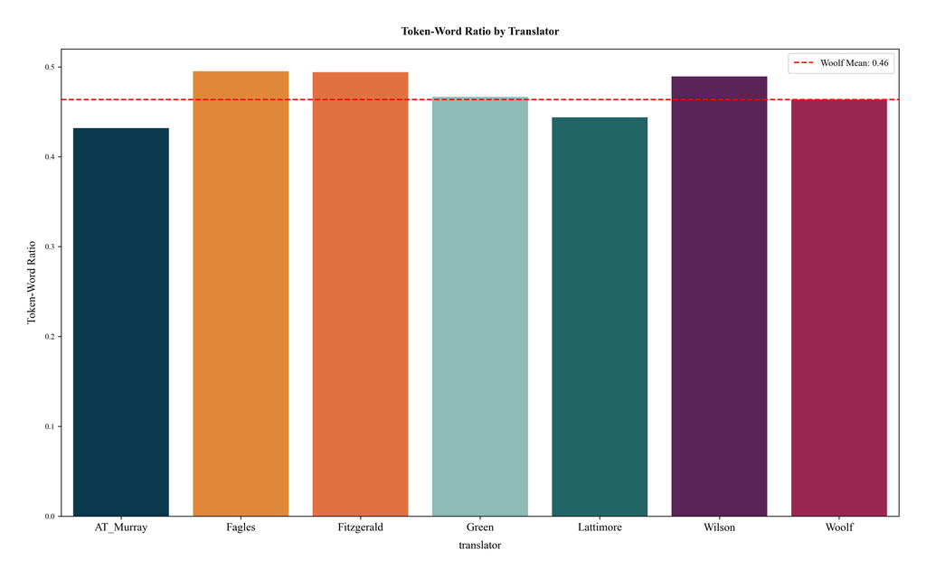

```
Baseline translator: Woolf with a ratio of 0.46
translator
AT_Murray    0.43
Fagles       0.50
Fitzgerald   0.49
Green        0.47
Lattimore    0.44
Wilson       0.49
Woolf        0.46
Name: token_word_ratio, dtype: float64
time: 588 ms (started: 2025-04-20 20:52:50 +02:00)
```

```python
# ----------------------------------------------------------------------
# Compute mean token-word ratio per translator
# This shows translation density: higher token-word ratios indicate
# more tokens per word, suggesting more complex or elaborate language choices
# ----------------------------------------------------------------------

df["token_word_ratio"] = df["num_tokens"] / df["num_words"]

baseline_translator = "Woolf"
baseline_ratio = df[df["translator"] == baseline_translator]["token_word_ratio"].mean()

translator_means = df.groupby("translator")["token_word_ratio"].mean().reset_index()

sns.barplot(data=translator_means, x="translator", y="token_word_ratio",
             palette=palette)

# Baseline (horizontal line for reference translator)
plt.axhline(baseline_ratio, color="red", linestyle="--",
            label=f"{baseline_translator} Mean: {baseline_ratio:.2f}")

plt.xlabel("Translator")
plt.ylabel("Token-Word Ratio")
plt.title("Token-Word Ratio by Translator")
plt.xticks()
plt.legend()
plt.savefig(output_path_plots + f"token_word_ratio-{nb_id}.png")
plt.show()
# ----------------------------------------------------------------------
print(f"Baseline translator: {baseline_translator} with a ratio of {baseline_ratio:.2f}")
print(df.groupby("translator")["token_word_ratio"].mean())
```

#### **b) Token quality check**

```python
# ----------------------------------------------------------------------
# First sentence extraction
# ----------------------------------------------------------------------

df['text_string'] = df['text'].apply(lambda x: "".join(x).replace("\n", "") if isinstance(x, list) else "")
df['sentences'] = df['text_string'].apply(lambda x: x.split(".") if isinstance(x, str) else [])
df['first_sentence'] = df['sentences'].apply(lambda x: x[0].strip() if len(x) > 0 else "")

# Group by 'translator' and extract the first sentence
first_sent_df = df.groupby("translator").first().reset_index()[["translator", "first_sentence"]]
pan.wide()
first_sent_df
```

```
✓ Wide display format applied
```

|  | translator | first_sentence |
| --- | --- | --- |
| 0 | AT_Murray | Tell me, O Muse, of that many-sided hero whotraveled far and wide after he had sacked the famous town of Troy |
| 1 | Fagles | Sing to me of the man, Muse, the man of twists and turns …driven time and again off course, once he had plunderedthe hallowed heights of Troy |
| 2 | Fitzgerald | Sing in me, Muse, and through me tell the story of that man skilled in all ways of contending, the wanderer, harried for years on end, after he plundered the stronghold on the proud height of Troy |
| 3 | Green | The man, Muse—tell me about that resourceful man, who wanderedfar and wide, when he’d sacked Troy’s sacred citadel:many men’s townships he saw, and learned their ways of thinking,many the griefs h... |
| 4 | Lattimore | Tell me, Muse, of the man of many ways, who was drivenfar journeys, after he had sacked Troy's sacred citadel |
| 5 | Wilson | Tell me about a complicated man |
| 6 | Woolf | As the streets that lead from the Strand to the Embankment are verynarrow, it is better not to walk down them arm-in-arm |

```
time: 16.1 ms (started: 2025-04-20 20:52:51 +02:00)
```

```python
# ----------------------------------------------------------------------
# Proem
# ----------------------------------------------------------------------

def extract_first_lines(df):
    """
    Extracts the first 9 lines of Book 1 for each translator, i.e., the proem.

    Args:
        df (pd.DataFrame): The input DataFrame containing columns 'translator', 'book_num', and 'text'.

    Returns:
        pd.DataFrame: A new DataFrame with translators and their first 9 lines from Book 1.
    """
    first_lines_data = []

    for translator in df["translator"].unique():
        book1_text = df.loc[(df["translator"] == translator) & (df["book_num"] == 1), "text"].values

        if len(book1_text) > 0:  # Ensure there's data
            first_9_lines = "".join(book1_text[0][:9])  # Get first 9 lines
            first_lines_data.append({"translator": translator, "proem": first_9_lines})

    # Convert the list to a DataFrame
    df_proem = pd.DataFrame(first_lines_data)
    return df_proem

pan.wide()
df_proem = extract_first_lines(df)
df_proem
```

```
✓ Wide display format applied
```

|  | translator | proem |
| --- | --- | --- |
| 0 | AT_Murray | Tell me, O Muse, of that many-sided hero who\ntraveled far and wide after he had sacked the famous town of Troy . Many cities did he visit, and many were\nthe people with whose customs and thinkin... |
| 1 | Fitzgerald | Sing in me, Muse, and through me tell the story \nof that man skilled in all ways of contending, \nthe wanderer, harried for years on end, \nafter he plundered the stronghold \non the proud height... |
| 2 | Lattimore | Tell me, Muse, of the man of many ways, who was driven\nfar journeys, after he had sacked Troy's sacred citadel.\nMany were they whose cities he saw, whose minds he learned of,\nmany the pains he ... |
| 3 | Fagles | Sing to me of the man, Muse, the man of twists and turns …\ndriven time and again off course, once he had plundered\nthe hallowed heights of Troy.\nMany cities of men he saw and learned their mind... |
| 4 | Wilson | Tell me about a complicated man.\nMuse, tell me how he wandered and was lost\nwhen he had wrecked the holy town of Troy,\nand where he went, and who he met, the pain\nhe suﬀered in the storms at s... |
| 5 | Green | The man, Muse—tell me about that resourceful man, who wandered\nfar and wide, when he’d sacked Troy’s sacred citadel:\nmany men’s townships he saw, and learned their ways of thinking,\nmany the gr... |
| 6 | Woolf | As the streets that lead from the Strand to the Embankment are very\nnarrow, it is better not to walk down them arm-in-arm. If you persist,\nlawyers’ clerks will have to make flying leaps into the... |

```
time: 5 ms (started: 2025-04-20 20:52:51 +02:00)
```

```python
fagles_proem = df_proem.loc[df_proem["translator"] == "Fagles", "proem"].values[0]
print(f'Fagles\'s excellent proem:\n\n"\n{fagles_proem}"')
```

```
Fagles's excellent proem:

"
Sing to me of the man, Muse, the man of twists and turns …
driven time and again off course, once he had plundered
the hallowed heights of Troy.
Many cities of men he saw and learned their minds,
many pains he suffered, heartsick on the open sea,
fighting to save his life and bring his comrades home.
But he could not save them from disaster, hard as he strove—
the recklessness of their own ways destroyed them all,
the blind fools, they devoured the cattle of the Sun
"
time: 788 μs (started: 2025-04-20 20:52:51 +02:00)
```

```python
# Resetting df
df.drop(df[['first_sentence', 'sentences', 'num_words',
            'num_tokens', 'diff', 'token_word_ratio',
            'text_string']], axis=1, inplace=True)
pan.reset()
```

```
✓ Pandas display set to e_pandisplay defaults!
	 »----> use pan.<func>
time: 2.47 ms (started: 2025-04-20 20:52:51 +02:00)
```

## **III. Type-Token Ratio (TTR)**

**Type-Token Ratio (TTR)** is a key measure of lexical diversity, calculated as the number of unique words (**types**) divided by the total word count (**tokens**). It provides insight into a translator’s lexical choices when rendering the same source text.

- A **higher TTR** suggests a richer vocabulary, possibly reflecting an effort to capture nuances or stylistic complexity.
- A **lower TTR** may indicate a more repetitive or constrained word choice, potentially prioritizing accessibility or fidelity to the original.

### **TTR Formula**

$$TTR = \left( \frac{\text{Unique Words}}{\text{Total Words}} \right) \times 100$$

```python
# ----------------------------------------------------------------------
# Compute TTR
# ----------------------------------------------------------------------

df["ttr"] = df["tokens"].apply(lambda x: (len(set(x)) / len(x) * 100) if x else 0)
```

```
time: 17.7 ms (started: 2025-04-20 20:52:51 +02:00)
```

```python
# ----------------------------------------------------------------------
# TTR by translator
# ----------------------------------------------------------------------

ttr_by_translator = {}
for translator in translators:
    ttr_by_translator[translator] = df[df["translator"] == translator]["ttr"].tolist()

# TTR DF by translator
if 'book_num' not in df.columns:
    df['book_num'] = [f"Book_num_{i+1}" for i in range(1, 25)] * len(translators)
ttr_df = df.pivot(index='book_num', columns='translator', values='ttr')

# Reorder columns
ttr_df = ttr_df[translators]
ttr_df.T
```

| book_num translator | 1 | 2 | 3 | 4 | 5 | 6 | 7 | 8 | 9 | 10 | 11 | 12 | 13 | 14 | 15 | 16 | 17 | 18 | 19 | 20 | 21 | 22 | 23 | 24 |
| --- | --- | --- | --- | --- | --- | --- | --- | --- | --- | --- | --- | --- | --- | --- | --- | --- | --- | --- | --- | --- | --- | --- | --- | --- |
| AT_Murray | 48.94 | 48.62 | 45.90 | 40.54 | 48.72 | 51.94 | 52.80 | 46.99 | 44.85 | 43.40 | 46.20 | 47.43 | 50.69 | 45.05 | 41.30 | 43.01 | 42.00 | 49.08 | 46.78 | 50.31 | 46.12 | 43.73 | 50.44 | 48.24 |
| Fitzgerald | 53.27 | 55.35 | 50.16 | 46.76 | 57.68 | 58.87 | 61.10 | 54.00 | 54.89 | 52.74 | 51.96 | 56.00 | 55.68 | 51.93 | 51.43 | 51.47 | 48.62 | 57.30 | 50.61 | 60.28 | 56.28 | 53.05 | 59.78 | 54.22 |
| Lattimore | 45.94 | 45.54 | 42.43 | 35.98 | 45.94 | 51.87 | 49.41 | 41.15 | 42.79 | 41.19 | 42.64 | 44.07 | 46.33 | 45.12 | 40.87 | 41.72 | 40.44 | 47.18 | 42.89 | 50.03 | 43.59 | 41.44 | 48.69 | 42.61 |
| Fagles | 51.29 | 54.49 | 50.19 | 44.50 | 53.34 | 56.51 | 56.67 | 48.51 | 50.60 | 48.18 | 47.61 | 53.93 | 54.49 | 50.84 | 47.40 | 47.85 | 47.27 | 55.47 | 48.75 | 56.36 | 51.53 | 50.35 | 54.84 | 50.58 |
| Wilson | 51.59 | 53.45 | 50.20 | 43.86 | 52.96 | 55.78 | 56.28 | 49.10 | 50.38 | 49.59 | 49.37 | 53.03 | 55.56 | 51.48 | 47.34 | 48.07 | 47.90 | 55.07 | 50.37 | 57.00 | 52.10 | 49.57 | 54.05 | 49.29 |
| Green | 51.53 | 52.14 | 48.52 | 42.73 | 51.98 | 55.96 | 55.71 | 47.26 | 49.53 | 47.19 | 47.82 | 50.35 | 52.95 | 49.71 | 47.02 | 47.62 | 45.40 | 52.90 | 47.76 | 55.08 | 47.96 | 45.41 | 53.56 | 48.43 |
| Woolf | 54.24 | 56.24 | 51.32 | 49.25 | 61.27 | 53.92 | 69.98 | 63.46 | 46.29 | 55.83 | 50.66 | 46.82 | 67.19 | 47.49 | 49.44 | 50.10 | 49.36 | 67.64 | 45.52 | 50.22 | 50.71 | 53.84 | 59.47 | 47.21 |

```
time: 8.7 ms (started: 2025-04-20 20:52:51 +02:00)
```

```python
# ----------------------------------------------------------------------
# Shapiro-Wilk test for normality
# ----------------------------------------------------------------------

for translator in translators:
    # Get the TTR data for this translator
    ttr_data = ttr_by_translator[translator]

    # Perform Shapiro-Wilk test
    stat, p_value = stats.shapiro(ttr_data)

    # Print results
    print(f"Shapiro-Wilk test for \n{translator}'s data: T-statistic={stat:.4f}, p-value={p_value:.4f}")

    # Interpret results
    if p_value < 0.05:
        print(f"{translator}'s TTR data is NOT normally distributed.")
    else:
        print(f"{translator}'s TTR data is NORMALLY distributed.")

    print()
```

```
Shapiro-Wilk test for
AT_Murray's data: T-statistic=0.9797, p-value=0.8908
AT_Murray's TTR data is NORMALLY distributed.

Shapiro-Wilk test for
Fitzgerald's data: T-statistic=0.9861, p-value=0.9769
Fitzgerald's TTR data is NORMALLY distributed.

Shapiro-Wilk test for
Lattimore's data: T-statistic=0.9664, p-value=0.5792
Lattimore's TTR data is NORMALLY distributed.

Shapiro-Wilk test for
Fagles's data: T-statistic=0.9492, p-value=0.2606
Fagles's TTR data is NORMALLY distributed.

Shapiro-Wilk test for
Wilson's data: T-statistic=0.9715, p-value=0.7034
Wilson's TTR data is NORMALLY distributed.

Shapiro-Wilk test for
Green's data: T-statistic=0.9645, p-value=0.5361
Green's TTR data is NORMALLY distributed.

Shapiro-Wilk test for
Woolf's data: T-statistic=0.8847, p-value=0.0103
Woolf's TTR data is NOT normally distributed.

time: 12.6 ms (started: 2025-04-20 20:52:51 +02:00)
```

```python
# ----------------------------------------------------------------------
# One-way ANOVA
# ----------------------------------------------------------------------

translator_names = translators
ttr_values = [ttr_by_translator[translator] for translator in translator_names]

# One-way ANOVA
f_stat, p_value = stats.f_oneway(*ttr_values)
print(f"F-statistic: {f_stat:.4f}, P-value: {p_value:.4f}")

if p_value < 0.05:
    print("There are statistically significant differences in TTR among the translators.")
else:
    print("There are no statistically significant differences in TTR among the translators.")
```

```
F-statistic: 18.6346, P-value: 0.0000
There are statistically significant differences in TTR among the translators.
time: 1.24 ms (started: 2025-04-20 20:52:51 +02:00)
```

```python
# ----------------------------------------------------------------------
# Pairwise t-tests with Bonferroni correction
# ----------------------------------------------------------------------

print("Pairwise t-tests with Bonferroni correction:\n")

# Number of comparisons for Bonferroni correction
num_comparisons = len(list(combinations(range(len(translator_names)), 2)))

for i, j in combinations(range(len(translator_names)), 2):
    t_stat, p_val = stats.ttest_ind(ttr_values[i], ttr_values[j])

    # Apply Bonferroni correction
    adj_p_val = min(p_val * num_comparisons, 1.0)

    # Calculate mean difference
    mean_diff = np.mean(ttr_values[i]) - np.mean(ttr_values[j])

    # Determine significance
    is_significant = "SIGNIFICANT" if adj_p_val < 0.05 else "NOT significant"

    print(f"{translator_names[i]} vs {translator_names[j]}: Diff = {mean_diff:.4f}, p = {adj_p_val:.4f} - {is_significant}")
```

```
Pairwise t-tests with Bonferroni correction:

AT_Murray vs Fitzgerald: Diff = -7.5148, p = 0.0000 - SIGNIFICANT
AT_Murray vs Lattimore: Diff = 2.6355, p = 0.2486 - NOT significant
AT_Murray vs Fagles: Diff = -4.5204, p = 0.0007 - SIGNIFICANT
AT_Murray vs Wilson: Diff = -4.5955, p = 0.0003 - SIGNIFICANT
AT_Murray vs Green: Diff = -2.9757, p = 0.0865 - NOT significant
AT_Murray vs Woolf: Diff = -7.2653, p = 0.0010 - SIGNIFICANT
Fitzgerald vs Lattimore: Diff = 10.1503, p = 0.0000 - SIGNIFICANT
Fitzgerald vs Fagles: Diff = 2.9944, p = 0.1204 - NOT significant
Fitzgerald vs Wilson: Diff = 2.9193, p = 0.1190 - NOT significant
Fitzgerald vs Green: Diff = 4.5391, p = 0.0014 - SIGNIFICANT
Fitzgerald vs Woolf: Diff = 0.2495, p = 1.0000 - NOT significant
Lattimore vs Fagles: Diff = -7.1559, p = 0.0000 - SIGNIFICANT
Lattimore vs Wilson: Diff = -7.2310, p = 0.0000 - SIGNIFICANT
Lattimore vs Green: Diff = -5.6112, p = 0.0000 - SIGNIFICANT
Lattimore vs Woolf: Diff = -9.9008, p = 0.0000 - SIGNIFICANT
Fagles vs Wilson: Diff = -0.0751, p = 1.0000 - NOT significant
Fagles vs Green: Diff = 1.5447, p = 1.0000 - NOT significant
Fagles vs Woolf: Diff = -2.7449, p = 1.0000 - NOT significant
Wilson vs Green: Diff = 1.6198, p = 1.0000 - NOT significant
Wilson vs Woolf: Diff = -2.6698, p = 1.0000 - NOT significant
Green vs Woolf: Diff = -4.2896, p = 0.2428 - NOT significant
time: 14.8 ms (started: 2025-04-20 20:52:51 +02:00)
```

```python
# ----------------------------------------------------------------------
# Cohen's d for effect size
# ----------------------------------------------------------------------
# Function to calculate Cohen's d
def cohens_d(group1, group2):
   n1, n2 = len(group1), len(group2)
   var1, var2 = np.var(group1, ddof=1), np.var(group2, ddof=1)
   pooled_std = np.sqrt(((n1 - 1) * var1 + (n2 - 1) * var2) / (n1 + n2 - 2))
   mean_diff = np.mean(group1) - np.mean(group2)
   return mean_diff / pooled_std

# Calculate Cohen's d for significant differences
significant_pairs = [
   ('Lattimore', 'Wilson'),
   ('Fagles', 'Wilson'),
   ('Wilson', 'Green'),
   ('Fitzgerald', 'Wilson'),
   ('Fitzgerald', 'Green'),
   ('Fitzgerald', 'Lattimore'),
   ('Fitzgerald', 'Fagles'),
   ('Lattimore', 'Fagles'),
   ('Lattimore', 'Green'),
   ('Fagles', 'Green'),
   ('Woolf', 'Wilson'),
   ('Woolf', 'Green'),
   ('Woolf', 'Lattimore'),
   ('Woolf', 'Fagles'),
   ('Woolf', 'Fitzgerald'),
   ('Woolf', 'AT_Murray'),
   ('AT_Murray', 'Wilson'),
   ('AT_Murray', 'Green'),
   ('AT_Murray', 'Lattimore'),
   ('AT_Murray', 'Fagles'),
   ('AT_Murray', 'Fitzgerald'),
   ('AT_Murray', 'Woolf')
]

small_differences = []
medium_differences = []
large_differences = []


for pair in significant_pairs:
   translator1, translator2 = pair
   group1 = ttr_by_translator[translator1]
   group2 = ttr_by_translator[translator2]
   d = cohens_d(group1, group2)
   t_stat, p_value = stats.ttest_ind(group1, group2)
   print(f"{translator1} vs {translator2}:")
   print(f"Cohen's d: {d:.4f}")
   print(f"T-statistic: {t_stat:.4f}")
   print(f"P-value: {p_value:.4e}")

   # Interpret effect size
   if abs(d) < 0.2:
       interpretation = "small"
       small_differences.append((translator1, translator2, d))

   elif abs(d) < 0.5:
       interpretation = "medium"
       medium_differences.append((translator1, translator2, d))

   else:
       interpretation = "large"
       # Store pairs with large effect sizes
       large_differences.append((translator1, translator2, d))

   print(f"Effect size interpretation: {interpretation}")
   print()
```

```
Lattimore vs Wilson:
Cohen's d: -2.1067
T-statistic: -7.2977
P-value: 3.2647e-09
Effect size interpretation: large

Fagles vs Wilson:
Cohen's d: -0.0224
T-statistic: -0.0777
P-value: 9.3841e-01
Effect size interpretation: small

Wilson vs Green:
Cohen's d: 0.4818
T-statistic: 1.6691
P-value: 1.0190e-01
Effect size interpretation: medium

Fitzgerald vs Wilson:
Cohen's d: 0.8379
T-statistic: 2.9026
P-value: 5.6648e-03
Effect size interpretation: large

Fitzgerald vs Green:
Cohen's d: 1.2643
T-statistic: 4.3796
P-value: 6.8063e-05
Effect size interpretation: large

Fitzgerald vs Lattimore:
Cohen's d: 2.7760
T-statistic: 9.6164
P-value: 1.3910e-12
Effect size interpretation: large

Fitzgerald vs Fagles:
Cohen's d: 0.8366
T-statistic: 2.8982
P-value: 5.7325e-03
```

[output cut: 78 more lines]

```
Effect size interpretation: large

AT_Murray vs Fitzgerald:
Cohen's d: -2.1265
T-statistic: -7.3665
P-value: 2.5766e-09
Effect size interpretation: large

AT_Murray vs Woolf:
Cohen's d: -1.2943
T-statistic: -4.4835
P-value: 4.8584e-05
Effect size interpretation: large

time: 16 ms (started: 2025-04-20 20:52:51 +02:00)
```

```python
large_differences
```

```
[('Lattimore', 'Wilson', np.float64(-2.1066690351877684)),
 ('Fitzgerald', 'Wilson', np.float64(0.8379059553922076)),
 ('Fitzgerald', 'Green', np.float64(1.2642836783293723)),
 ('Fitzgerald', 'Lattimore', np.float64(2.776022112113443)),
 ('Fitzgerald', 'Fagles', np.float64(0.8366316376564336)),
 ('Lattimore', 'Fagles', np.float64(-2.027770019343238)),
 ('Lattimore', 'Green', np.float64(-1.5849993007225294)),
 ('Woolf', 'Green', np.float64(0.7593344024764881)),
 ('Woolf', 'Lattimore', np.float64(1.73960507142481)),
 ('Woolf', 'AT_Murray', np.float64(1.2942701628037707)),
 ('AT_Murray', 'Wilson', np.float64(-1.3919320837888793)),
 ('AT_Murray', 'Green', np.float64(-0.871766736591539)),
 ('AT_Murray', 'Lattimore', np.float64(0.7566813735640675)),
 ('AT_Murray', 'Fagles', np.float64(-1.328838698983698)),
 ('AT_Murray', 'Fitzgerald', np.float64(-2.126536150446062)),
 ('AT_Murray', 'Woolf', np.float64(-1.2942701628037707))]
```

```
time: 1.55 ms (started: 2025-04-20 20:52:51 +02:00)
```

```python
medium_differences
```

```
[('Wilson', 'Green', np.float64(0.48181604529503674)),
 ('Fagles', 'Green', np.float64(0.44639242330348305)),
 ('Woolf', 'Wilson', np.float64(0.478262993229905)),
 ('Woolf', 'Fagles', np.float64(0.4865061309048371))]
```

```
time: 1.86 ms (started: 2025-04-20 20:52:51 +02:00)
```

```python
small_differences
```

```
[('Fagles', 'Wilson', np.float64(-0.022427690380644072)),
 ('Woolf', 'Fitzgerald', np.float64(-0.04360434685315158))]
```

```
time: 1.08 ms (started: 2025-04-20 20:52:51 +02:00)
```

Fagles, Wilson, and Green (to an extent) are the closest TTR-wise.

```python
# ----------------------------------------------------------------------
# Mixed-effects model
# ----------------------------------------------------------------------

# 'ttr' as dependent variable
# 'translator' as fixed effect
# 'book_num' as random effect

# C(translator) bc 'translator' is categorical
# The random intercept is specified as '1 | book_num' = Murray's book_num
# The model will estimate the effect of translator on TTR while accounting for the random effect of book_num
model = smf.mixedlm("ttr ~ C(translator)", data=df, groups=df["book_num"])

results = model.fit()

print(results.summary())

# The results:
# estimated coefficients for each translator,
# standard errors, t-values, and p-values.
```

```
                Mixed Linear Model Regression Results
======================================================================
Model:                 MixedLM      Dependent Variable:      ttr
No. Observations:      168          Method:                  REML
No. Groups:            24           Scale:                   6.2919
Min. group size:       7            Log-Likelihood:          -417.7738
Max. group size:       7            Converged:               Yes
Mean group size:       7.0
----------------------------------------------------------------------
                            Coef.  Std.Err.   z    P>|z| [0.025 0.975]
----------------------------------------------------------------------
Intercept                   46.795    0.860 54.412 0.000 45.110 48.481
C(translator)[T.Fagles]      4.520    0.724  6.243 0.000  3.101  5.940
C(translator)[T.Fitzgerald]  7.515    0.724 10.378 0.000  6.096  8.934
C(translator)[T.Green]       2.976    0.724  4.110 0.000  1.556  4.395
C(translator)[T.Lattimore]  -2.635    0.724 -3.640 0.000 -4.055 -1.216
C(translator)[T.Wilson]      4.596    0.724  6.346 0.000  3.176  6.015
C(translator)[T.Woolf]       7.265    0.724 10.033 0.000  5.846  8.684
Group Var                   11.459    1.569
======================================================================

time: 24 ms (started: 2025-04-20 20:52:51 +02:00)
```

```python
# ----------------------------------------------------------------------
# Mixed-effects model
# ----------------------------------------------------------------------

# 'ttr' as dependent variable
# 'translator' as fixed effect
# 'book_num' as random effect

# C(translator) bc 'translator' is categorical
# The random intercept is specified as '1 | book_num' = Murray's book_num
# The model will estimate the effect of translator on TTR while accounting for the random effect of book_num
model = smf.mixedlm("ttr ~ C(translator)", data=df, groups=df["book_num"])

results = model.fit()

print(results.summary())

# The results:
# estimated coefficients for each translator,
# standard errors, t-values, and p-values.
```

```
                Mixed Linear Model Regression Results
======================================================================
Model:                 MixedLM      Dependent Variable:      ttr
No. Observations:      168          Method:                  REML
No. Groups:            24           Scale:                   6.2919
Min. group size:       7            Log-Likelihood:          -417.7738
Max. group size:       7            Converged:               Yes
Mean group size:       7.0
----------------------------------------------------------------------
                            Coef.  Std.Err.   z    P>|z| [0.025 0.975]
----------------------------------------------------------------------
Intercept                   46.795    0.860 54.412 0.000 45.110 48.481
C(translator)[T.Fagles]      4.520    0.724  6.243 0.000  3.101  5.940
C(translator)[T.Fitzgerald]  7.515    0.724 10.378 0.000  6.096  8.934
C(translator)[T.Green]       2.976    0.724  4.110 0.000  1.556  4.395
C(translator)[T.Lattimore]  -2.635    0.724 -3.640 0.000 -4.055 -1.216
C(translator)[T.Wilson]      4.596    0.724  6.346 0.000  3.176  6.015
C(translator)[T.Woolf]       7.265    0.724 10.033 0.000  5.846  8.684
Group Var                   11.459    1.569
======================================================================

time: 24.5 ms (started: 2025-04-20 20:52:51 +02:00)
```

#### **Interpreting the Mixed-Effects Model Results**

This mixed-effects model examines how TTR (Type-Token Ratio) varies across translators while accounting for book-specific effects. Here's a brief interpretation:

**Effect Size Interpretation** The coefficients represent the difference in TTR between each translator and the reference translator (AT_Murray, who is represented by the Intercept):

- **Fitzgerald shows the largest effect (7.515)**, indicating his translation has significantly higher lexical diversity than Murray's (about 16% higher)
- Woolf follows closely (7.265), with similarly high lexical diversity Wilson and Fagles show moderate increases (4.596 and 4.520)
- Green shows a smaller increase (2.976) **Lattimore is the only translator with lower lexical diversity than Murray (-2.635)**

**Statistical Significance** All effects are highly significant (p < 0.001), indicating these differences are not due to random chance.

The **"Group Var" (11.459) indicates substantial variation across books**, suggesting certain parts of the Odyssey consistently show different lexical patterns regardless of translator.

```python
# Create a copy of the translator column
df['translator_recoded'] = df['translator']

# Recode the values to change the reference level to Woolf
# Option 1: Using pandas categorical with ordered=True
df['translator_recoded'] = pd.Categorical(
    df['translator_recoded'],
    categories=['Woolf'] + [t for t in df['translator'].unique() if t != 'Woolf'],
    ordered=True
)

# Option 2: Alternative approach using string manipulation
# df['translator_recoded'] = df['translator_recoded'].map(
#     lambda x: 'A_' + x if x == 'Woolf' else ('Z_' + x if x == 'AT_Murray' else x)
# )

# Refit the model with the recoded variable
model = smf.mixedlm("ttr ~ C(translator_recoded)", data=df, groups=df["book_num"])
results = model.fit()
print(results.summary())
```

```
                     Mixed Linear Model Regression Results
================================================================================
Model:                     MixedLM         Dependent Variable:         ttr
No. Observations:          168             Method:                     REML
No. Groups:                24              Scale:                      6.2919
Min. group size:           7               Log-Likelihood:             -417.7738
Max. group size:           7               Converged:                  Yes
Mean group size:           7.0
--------------------------------------------------------------------------------
                                    Coef.  Std.Err.    z    P>|z|  [0.025 0.975]
--------------------------------------------------------------------------------
Intercept                           54.061    0.860  62.860 0.000  52.375 55.746
C(translator_recoded)[T.AT_Murray]  -7.265    0.724 -10.033 0.000  -8.684 -5.846
C(translator_recoded)[T.Fitzgerald]  0.250    0.724   0.345 0.730  -1.170  1.669
C(translator_recoded)[T.Lattimore]  -9.901    0.724 -13.673 0.000 -11.320 -8.482
C(translator_recoded)[T.Fagles]     -2.745    0.724  -3.791 0.000  -4.164 -1.326
C(translator_recoded)[T.Wilson]     -2.670    0.724  -3.687 0.000  -4.089 -1.251
C(translator_recoded)[T.Green]      -4.290    0.724  -5.924 0.000  -5.709 -2.870
Group Var                           11.459    1.569
================================================================================

time: 23.5 ms (started: 2025-04-20 20:52:51 +02:00)
```

Interpretation of Mixed-Effects Model Results with Woolf as Reference These results show how each translator's TTR (Type-Token Ratio) compares to Woolf's translation when accounting for book-specific effects: Key Findings

Lattimore shows the largest negative difference (-9.901), with approximately 18% lower lexical diversity Green shows a substantial difference (-4.290) AT_Murray shows a large difference (-7.265) Fagles and Wilson show similar moderate differences (-2.745 and -2.670 respectively)

Practical Significance This analysis reveals distinct tiers of vocabulary richness in Odyssey translations:

Highest tier (statistically equivalent): Woolf and Fitzgerald Middle tier: Wilson and Fagles Lower tier: Green and AT_Murray Lowest tier: Lattimore

The significant book-to-book variation (Group Var = 11.459) remains consistent with your previous model, confirming that certain parts of the Odyssey show different lexical patterns regardless of translator.

```python
# ----------------------------------------------------------------------
# Standardized TTR (STTR)
# ----------------------------------------------------------------------

def calculate_sttr(tokens, segment_size=100):
    """
    Calculates Standardized Type-Token Ratio (STTR).

    Args:
        tokens (list): List of tokens (words).
        segment_size (int): Size of each segment to calculate TTR on.

    Returns:
        float: STTR value.
    """
    if len(tokens) < segment_size:
        return len(set(tokens)) / len(tokens) * 100  # Fallback to regular TTR if too short

    num_segments = len(tokens) // segment_size
    ttr_values = []

    for i in range(num_segments):
        segment = tokens[i * segment_size: (i + 1) * segment_size]
        ttr = len(set(segment)) / len(segment) * 100
        ttr_values.append(ttr)

    return np.mean(ttr_values)

# Apply STTR calculation to your DataFrame
df['sttr'] = df['tokens'].apply(calculate_sttr)
```

```
time: 15.7 ms (started: 2025-04-20 20:52:51 +02:00)
```

```python
# ----------------------------------------------------------------------
# Moving-Average TTR
# ----------------------------------------------------------------------

def calculate_moving_average_ttr(tokens, window_size=100):
    """
    Calculates Moving-Average Type-Token Ratio.

    Args:
        tokens (list): List of tokens (words).
        window_size (int): Size of the moving window.

    Returns:
        list: List of moving-average TTR values.
    """
    if len(tokens) < window_size:
        return [len(set(tokens)) / len(tokens) * 100]  # Fallback to regular TTR if too short

    moving_average_ttr = []
    for i in range(window_size, len(tokens) + 1):
        window = tokens[i - window_size:i]
        ttr = len(set(window)) / len(window) * 100
        moving_average_ttr.append(ttr)
    return moving_average_ttr

# Apply Moving-Average TTR calculation to your DataFrame
# This creates a new column with lists of TTR values for each book
df['moving_average_ttr'] = df['tokens'].apply(calculate_moving_average_ttr)

# Average STTR for each translator:
average_sttr_by_translator = df.groupby('translator')['sttr'].mean()
print("Average STTR by translator:\n", average_sttr_by_translator)
```

```
Average STTR by translator:
 translator
AT_Murray    86.96
Fagles       90.86
Fitzgerald   91.07
Green        89.33
Lattimore    86.58
Wilson       88.56
Woolf        88.09
Name: sttr, dtype: float64
time: 780 ms (started: 2025-04-20 20:52:51 +02:00)
```

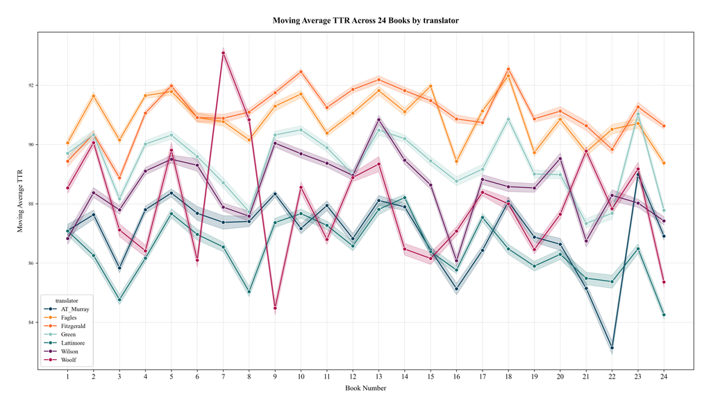

```
time: 4.83 s (started: 2025-04-20 20:52:52 +02:00)
```

```python
# ----------------------------------------------------------------------
# Plotting Moving-Average TTR
# ----------------------------------------------------------------------

# Explode the 'moving_average_ttr' column if it contains lists
if isinstance(df["moving_average_ttr"].iloc[0], list):  # Check if the column contains lists
    df = df.explode("moving_average_ttr")

# Convert to float (just in case)
df["moving_average_ttr"] = df["moving_average_ttr"].astype(float)

# Sort values by translator and book number to ensure correct order
df = df.sort_values(by=["translator", "book_num"])
plt.figure(figsize=(16, 9))

# Line plot: Moving Average TTR by translator
sns.lineplot(data=df, x="book_num", y="moving_average_ttr",
             hue="translator", marker="o", palette=palette)

plt.xlabel("Book Number", fontsize=12)
plt.ylabel("Moving Average TTR", fontsize=12)
plt.title("Moving Average TTR Across 24 Books by translator", fontsize=14)
plt.xticks(range(1, 25))  # Ensure x-axis labels from 1 to 24
plt.legend(title="translator")
plt.grid(True, linestyle="--", alpha=0.5)
plt.tight_layout()
plt.savefig(output_path_plots + f"moving_average_ttr-{nb_id}.png", dpi=400)
plt.show()
```

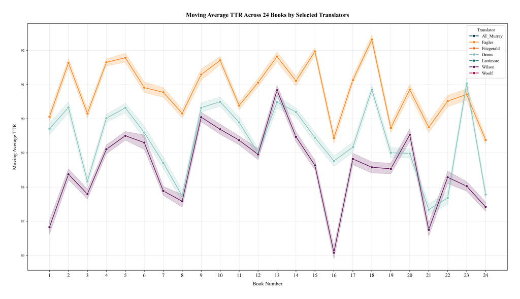

```
time: 2.93 s (started: 2025-04-20 20:52:57 +02:00)
```

```python
# ----------------------------------------------------------------------
# Plotting Moving-Average TTR
# ----------------------------------------------------------------------
# Subset of translators to include
selected_translators = ['Wilson', 'Fagles', 'Green']

# Create a filtered dataframe with only selected translators
df_subset = df[df['translator'].isin(selected_translators)]

# Explode the 'moving_average_ttr' column if it contains lists
if isinstance(df_subset["moving_average_ttr"].iloc[0], list): # Check if the column contains lists
   df_subset = df_subset.explode("moving_average_ttr")

# Convert to float (just in case)
df_subset["moving_average_ttr"] = df_subset["moving_average_ttr"].astype(float)

# Sort values by translator and book number to ensure correct order
df_subset = df_subset.sort_values(by=["translator", "book_num"])

plt.figure(figsize=(16, 9))

# Line plot: Moving Average TTR by translator
sns.lineplot(data=df_subset, x="book_num", y="moving_average_ttr",
            hue="translator", marker="o", palette=palette)

plt.xlabel("Book Number", fontsize=12)
plt.ylabel("Moving Average TTR", fontsize=12)
plt.title("Moving Average TTR Across 24 Books by Selected Translators", fontsize=14)
plt.xticks(range(1, 25)) # Ensure x-axis labels from 1 to 24
plt.legend(title="Translator")
plt.grid(True, linestyle="--", alpha=0.5)
plt.tight_layout()
plt.savefig(output_path_plots + f"moving_average_ttr_selected_01-{nb_id}.png", dpi=400)
plt.show()
```

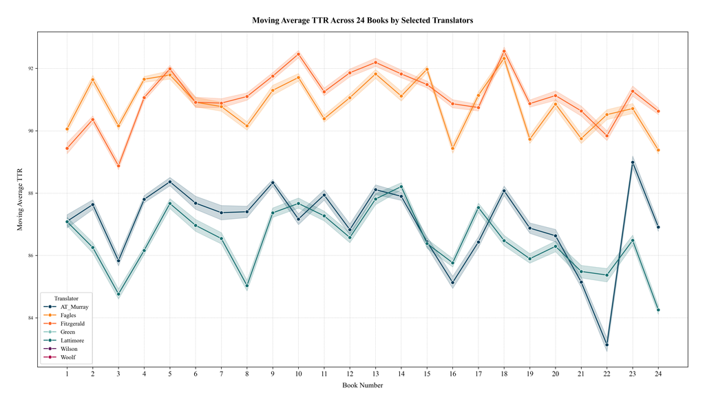

```
time: 3.31 s (started: 2025-04-20 20:53:00 +02:00)
```

```python
# ----------------------------------------------------------------------
# Plotting Moving-Average TTR
# ----------------------------------------------------------------------
# Subset of translators to include
selected_translators = ['Lattimore', 'Fagles', 'Fitzgerald', 'AT_Murray']

# Create a filtered dataframe with only selected translators
df_subset = df[df['translator'].isin(selected_translators)]

# Explode the 'moving_average_ttr' column if it contains lists
if isinstance(df_subset["moving_average_ttr"].iloc[0], list): # Check if the column contains lists
   df_subset = df_subset.explode("moving_average_ttr")

# Convert to float (just in case)
df_subset["moving_average_ttr"] = df_subset["moving_average_ttr"].astype(float)

# Sort values by translator and book number to ensure correct order
df_subset = df_subset.sort_values(by=["translator", "book_num"])

plt.figure(figsize=(16, 9))

# Line plot: Moving Average TTR by translator
sns.lineplot(data=df_subset, x="book_num", y="moving_average_ttr",
            hue="translator", marker="o", palette=palette)

plt.xlabel("Book Number", fontsize=12)
plt.ylabel("Moving Average TTR", fontsize=12)
plt.title("Moving Average TTR Across 24 Books by Selected Translators", fontsize=14)
plt.xticks(range(1, 25)) # Ensure x-axis labels from 1 to 24
plt.legend(title="Translator")
plt.grid(True, linestyle="--", alpha=0.5)
plt.tight_layout()
plt.savefig(output_path_plots + f"moving_average_ttr_selected_02-{nb_id}.png", dpi=400)
plt.show()
```

This shows that an author's agency and agenda is more relevant in TTR that time span or coetanity.

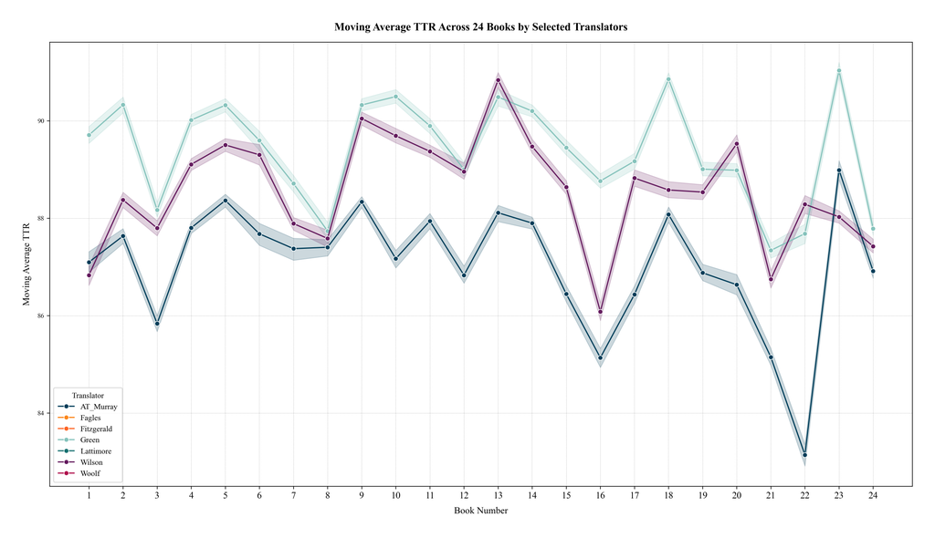

```
time: 2.83 s (started: 2025-04-20 20:53:03 +02:00)
```

```python
# ----------------------------------------------------------------------
# Plotting Moving-Average TTR
# ----------------------------------------------------------------------
# Subset of translators to include
selected_translators = ['Wilson', 'Green', 'AT_Murray']

# Create a filtered dataframe with only selected translators
df_subset = df[df['translator'].isin(selected_translators)]

# Explode the 'moving_average_ttr' column if it contains lists
if isinstance(df_subset["moving_average_ttr"].iloc[0], list): # Check if the column contains lists
   df_subset = df_subset.explode("moving_average_ttr")

# Convert to float (just in case)
df_subset["moving_average_ttr"] = df_subset["moving_average_ttr"].astype(float)

# Sort values by translator and book number to ensure correct order
df_subset = df_subset.sort_values(by=["translator", "book_num"])

plt.figure(figsize=(16, 9))

# Line plot: Moving Average TTR by translator
sns.lineplot(data=df_subset, x="book_num", y="moving_average_ttr",
            hue="translator", marker="o", palette=palette)

plt.xlabel("Book Number", fontsize=12)
plt.ylabel("Moving Average TTR", fontsize=12)
plt.title("Moving Average TTR Across 24 Books by Selected Translators", fontsize=14)
plt.xticks(range(1, 25)) # Ensure x-axis labels from 1 to 24
plt.legend(title="Translator")
plt.grid(True, linestyle="--", alpha=0.5)
plt.tight_layout()
plt.savefig(output_path_plots + f"moving_average_ttr_selected_03-{nb_id}.png", dpi=400)
plt.show()
```

Advancing Beyond Static Measures: The Value of Moving Average TTR Your insight about the moving average TTR being potentially superior for analyzing literary translations is well-founded. Let me develop this conclusion further: Moving Average TTR as a Superior Literary Metric The moving average TTR offers significant advantages when analyzing literary texts like the Odyssey:

Captures Narrative Flow: Literature unfolds sequentially, with vocabulary choices influenced by narrative context. The moving window approach mirrors how readers experience text - as a continuous flow rather than isolated segments. Reveals Stylistic Rhythms: Translations exhibit rhythmic patterns of lexical expansion and contraction that static measures miss. Some translators may employ richer vocabulary during battle scenes but simpler language during dialogues. Identifies Structural Patterns: The 24 books of the Odyssey contain distinct narrative sections (Telemachy, Odysseus's journey, etc.). Moving average TTR can reveal how translators adapt their approach to these varying narrative demands. Shows Translator Consistency: The moving average reveals whether translators maintain consistent lexical density throughout or vary their approach. For instance, Woolf and Fitzgerald show high overall TTR, but the moving average might reveal if this is consistent or concentrated in specific passages. Honors Literary Context: Unlike bag-of-words approaches that treat texts as unordered collections, moving average TTR respects that word choice in Homer depends heavily on what preceded it - both in narrative and poetic terms.

The significant differences you've found between translators (particularly the Woolf/Fitzgerald tier versus others) likely reflect fundamental philosophical approaches to translation. The moving average analysis could reveal whether these differences manifest consistently or vary strategically across the epic's different narrative modes - from divine councils to intimate conversations, from sea journeys to battle scenes. This sequential analysis aligns more closely with how literature functions as an art form, making it a more authentic measure of translators' stylistic choices in recreating Homer's epic.

## **IV. Zip's Law**

### **What and why:**

Zipf’s Law states that in a large text corpus, the frequency of a word is inversely proportional to its rank in the frequency table. This metric is relevant in comparing translations because it reveals how each translator balances **common vs. rare words**, shedding light on **lexical richness and stylistic choices**. This experiment provides empirical insight into whether a translator’s lexical distribution align with universal linguistic principles.

### **Implications for Translation Studies**

**a) natural linguistic flow:** Strong Zipfian adherence suggests that translators maintain natural language patterns, balancing high-frequency function words with low-frequency content words.

**b.1) Poetic stylization:** Deviations may indicate differences in lexical richness, syntactic choices, or stylistic adaptation in translation.  
**b.2) Philological fidelity:** 'Stylistic' shifts can also point out to genre requirements that, in the case of epic oral poetry, demand disticnt repetitive and formulaic patterns, epithets, etc.

### **Implementation**

Zipf’s Law states that in any natural language corpus, *the frequency of a word is inversely proportional to its rank:*

$$ f \propto \frac{1}{r} $$

Where:

- f = frequency of the word
- r = rank of the word (1st most frequent, 2nd most frequent, etc.)

Procedure:

1. Compute word frequencies for each translation.
2. Rank words from most to least frequent.
3. Plot word frequency vs. rank on a log-log scale.

```python
#--------------------------------------------------------------
# Zipf's Law
#--------------------------------------------------------------

# Step 1: Flatten tokens and count word frequencies for each translator
freq_dict = {
    translator: Counter(
        token for tokens in df[df["translator"] == translator]["tokens"] for token in tokens
    )
    for translator in translators
}

# Step 2: Convert word frequencies into sorted DataFrames with rank
df_word_freq_rank_dict = {
    translator: pd.DataFrame(freq.items(), columns=["word", "frequency"])
    .sort_values(by="frequency", ascending=False)
    .assign(rank=lambda df_: df_["frequency"].rank(method="first", ascending=False))
    for translator, freq in freq_dict.items()
}

# Example: Accessing a specific translator’s Zipf DataFrame
df_word_freq_rank_dict["AT_Murray"].tail(15).T  # View the top-ranked words for AT_Murray
```

|  | 3161 | 3162 | 3163 | 3165 | 3166 | 3168 | 3169 | 3171 | 3174 | 3175 | 3181 | 3184 | 3185 | 3189 | 3160 |
| --- | --- | --- | --- | --- | --- | --- | --- | --- | --- | --- | --- | --- | --- | --- | --- |
| word | enamel | pillars | lintel | mastiffs | consummate | expressly | coverings | persons | figures | pedestals | shuttles | fluttering | aspen | intelligent | blue |
| frequency | 1382 | 1382 | 1382 | 1382 | 1382 | 1382 | 1382 | 1382 | 1382 | 1382 | 1382 | 1382 | 1382 | 1382 | 1382 |
| rank | 6307.00 | 6308.00 | 6309.00 | 6310.00 | 6311.00 | 6312.00 | 6313.00 | 6314.00 | 6315.00 | 6316.00 | 6317.00 | 6318.00 | 6319.00 | 6320.00 | 6321.00 |

```
time: 1min 4s (started: 2025-04-20 20:53:06 +02:00)
```

```python
for translator in translators:
    total_tokens = sum(freq_dict[translator].values())
    print(f"{translator}: {total_tokens} tokens")
```

```
AT_Murray: 108550460 tokens
Fitzgerald: 119352282 tokens
Lattimore: 160108532 tokens
Fagles: 161535036 tokens
Wilson: 94772870 tokens
Green: 146986372 tokens
Woolf: 140780036 tokens
time: 981 μs (started: 2025-04-20 20:54:10 +02:00)
```

```python
# Step 2: Convert word frequencies to ranks

# Compute min and max ranks across all translators
min_rank = min(df["rank"].min() for df in df_word_freq_rank_dict.values())
max_rank = max(df["rank"].max() for df in df_word_freq_rank_dict.values())

# Compute min and max frequencies across all translators
min_freq = min(df["frequency"].min() for df in df_word_freq_rank_dict.values())
max_freq = max(df["frequency"].max() for df in df_word_freq_rank_dict.values())

print(f"Rank range: from the {min_rank}st to {max_rank}th less freq word (unique set and stopwords removed).")
print(f"Frequency range: low words in rank appear at least {min_freq} time and the most freq has {max_freq} instances.")
```

```
Rank range: from the 1.0st to 9024.0th less freq word (unique set and stopwords removed).
Frequency range: low words in rank appear at least 692 time and the most freq has 2014196 instances.
time: 2.28 ms (started: 2025-04-20 20:54:10 +02:00)
```

```
Figure saved as ././/lexical_A01_plots/Log-Log-lexical_A01.png at 400 DPI
```

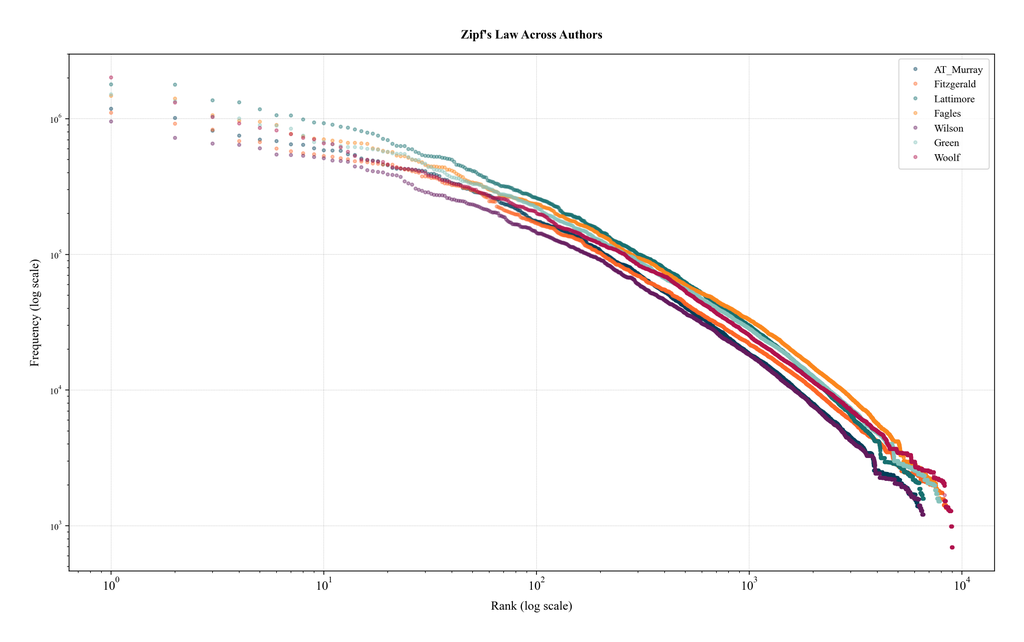

```
time: 1.74 s (started: 2025-04-20 20:54:10 +02:00)
```

```python
# Step 3: Plot Zipf's Law
def plot_zipfs_law(df_word_freq_rank_dict):
    fig, ax = plt.subplots()  # Create a figure and an axes object
    for author, df_zipf in df_word_freq_rank_dict.items():
        ax.loglog(df_zipf["rank"], df_zipf["frequency"],
                   label=author, marker=".", linestyle="None", alpha=0.4)

    ax.set_xlabel("Rank (log scale)")
    ax.set_ylabel("Frequency (log scale)")
    ax.set_title("Zipf's Law Across Authors")
    ax.legend()
    ax.grid(True, linestyle="--", linewidth=0.3, alpha=0.3)

    return fig  # Return the figure object

fig = plot_zipfs_law(df_word_freq_rank_dict)

chroma.save_figure(fig, f"Log-Log-{nb_id}.png")
```

```
Figure saved as ././/lexical_A01_plots/Log-Log-Fit-lexical_A01.png at 400 DPI
```

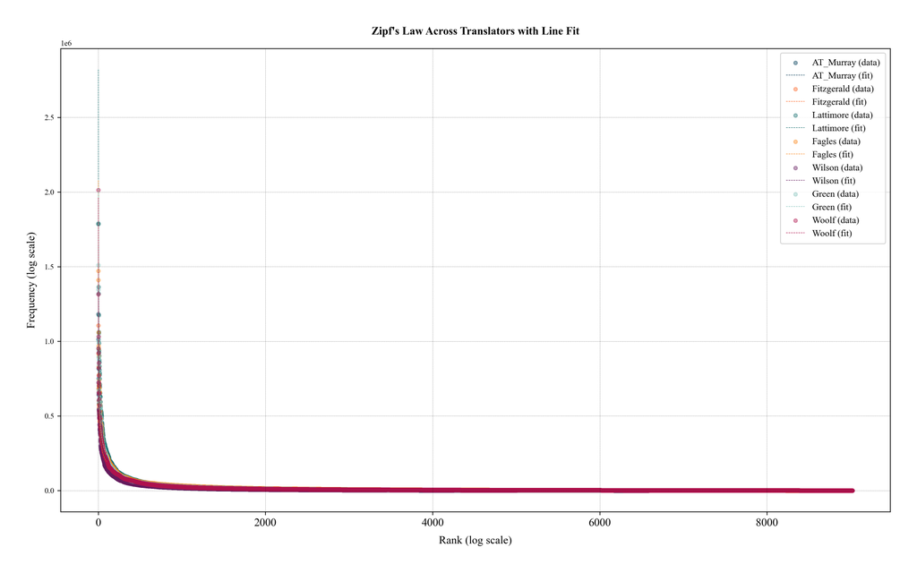

```
time: 1.68 s (started: 2025-04-20 20:54:12 +02:00)
```

```python
# Step 4: Fit a line to the log-log data

from sklearn.linear_model import LinearRegression

def plot_zipfs_law_with_fit(df_word_freq_rank_dict):
    fig, ax = plt.subplots()  # Create figure and axis

    for translator, df_zipf in df_word_freq_rank_dict.items():
        top_n = 100  # Adjust as needed
        df_zipf_top = df_zipf.head(top_n)

        # Log-transform the rank and frequency for fitting
        x = np.log(df_zipf_top["rank"].values.reshape(-1, 1))
        y = np.log(df_zipf_top["frequency"].values)

        # Fit a linear regression to the log-log data
        model = LinearRegression()
        model.fit(x, y)
        y_pred = model.predict(x)

        # Scatter plot of the actual data
        ax.scatter(df_zipf["rank"], df_zipf["frequency"], label=f"{translator} (data)", alpha=0.4, s=15)

        # Line of best fit
        ax.plot(df_zipf_top["rank"], np.exp(y_pred), label=f"{translator} (fit)", linestyle="--", lw=0.5)

    ax.set_xlabel("Rank (log scale)")
    ax.set_ylabel("Frequency (log scale)")
    ax.set_title("Zipf's Law Across Translators with Line Fit")
    ax.legend()
    ax.grid(True, which="both", linestyle="--", linewidth=0.3)

    return fig  # Return the figure object

fig = plot_zipfs_law_with_fit(df_word_freq_rank_dict)

# Save the figure properly
chroma.save_figure(fig, f"Log-Log-Fit-{nb_id}.png")
```

```python
#--------------------------------------------------------------
# Zipf's Law Analysis with Linear Regression
#--------------------------------------------------------------
from scipy.stats import linregress

# Create empty lists to store results
slopes = []
r_squared = []
p_values = []
std_errs = []
follows_zipf = []

# Perform linear regression in log-log space for each translator
for translator in translators:
    df_zipf = df_word_freq_rank_dict[translator]

    # Log-transform the rank and frequency
    #log_rank = np.log(df_zipf["rank"])
    #log_freq = np.log(df_zipf["frequency"])
    log_rank = np.log(df_zipf["rank"] + 1)  # Add a small constant to avoid log(0)
    log_freq = np.log(df_zipf["frequency"] + 1)

    # Perform linear regression
    slope, intercept, r_value, p_value, std_err = linregress(log_rank, log_freq)

    # Store results
    slopes.append(slope)
    r_squared.append(r_value**2)
    p_values.append(p_value)
    std_errs.append(std_err)
    follows_zipf.append(-1.2 < slope < -0.8)

    # Display individual results
    print(f"{translator}: Slope = {slope:}, R² = {r_value**2:}, p-value = {p_value:}")

    # Check if slope is close to -1 (Zipf's Law predicts ~ -1)
    if -1.2 < slope < -0.8:
        print(f"{translator}'s translation follows Zipf's Law.")
    else:
        print(f"{translator}'s translation deviates from Zipf's Law.")
    print("-" * 50)

# Create a summary dataframe
results_df = pd.DataFrame({
    'Translator': translators,
    'Slope': slopes,
    'R²': r_squared,
    'p-value': p_values,
    'Std Error': std_errs,
    'Follows Zipf\'s Law': follows_zipf
})

print("\nSummary of Zipf's Law Analysis:")
print(results_df)
```

```
AT_Murray: Slope = -1.1938277516804667, R² = 0.977157940827377, p-value = 0.0
AT_Murray's translation follows Zipf's Law.
--------------------------------------------------
Fitzgerald: Slope = -1.1157547600338376, R² = 0.9815849688620832, p-value = 0.0
Fitzgerald's translation follows Zipf's Law.
--------------------------------------------------
Lattimore: Slope = -1.2445595081994263, R² = 0.967711411988808, p-value = 0.0
Lattimore's translation deviates from Zipf's Law.
--------------------------------------------------
Fagles: Slope = -1.1701011452556676, R² = 0.9620972604470153, p-value = 0.0
Fagles's translation follows Zipf's Law.
--------------------------------------------------
Wilson: Slope = -1.169168818993014, R² = 0.972983373756506, p-value = 0.0
Wilson's translation follows Zipf's Law.
--------------------------------------------------
Green: Slope = -1.1715327968509333, R² = 0.9715509555418855, p-value = 0.0
Green's translation follows Zipf's Law.
--------------------------------------------------
Woolf: Slope = -1.1315580364789302, R² = 0.9715828921516424, p-value = 0.0
Woolf's translation follows Zipf's Law.
--------------------------------------------------

Summary of Zipf's Law Analysis:
  Translator   Slope  R²   p-value  Std Error  Follows Zipf's Law
0   AT_Murray -1.19  0.98 0.00     0.00         True
1  Fitzgerald -1.12  0.98 0.00     0.00         True
2   Lattimore -1.24  0.97 0.00     0.00        False
3      Fagles -1.17  0.96 0.00     0.00         True
4      Wilson -1.17  0.97 0.00     0.00         True
5       Green -1.17  0.97 0.00     0.00         True
6       Woolf -1.13  0.97 0.00     0.00         True
time: 6.18 ms (started: 2025-04-20 20:54:14 +02:00)
```

## **Interpreting the results:**

The regression model of Zipf's Law finds an extremely strong correlation between rank and frequency with very low variability in the estimated slope.

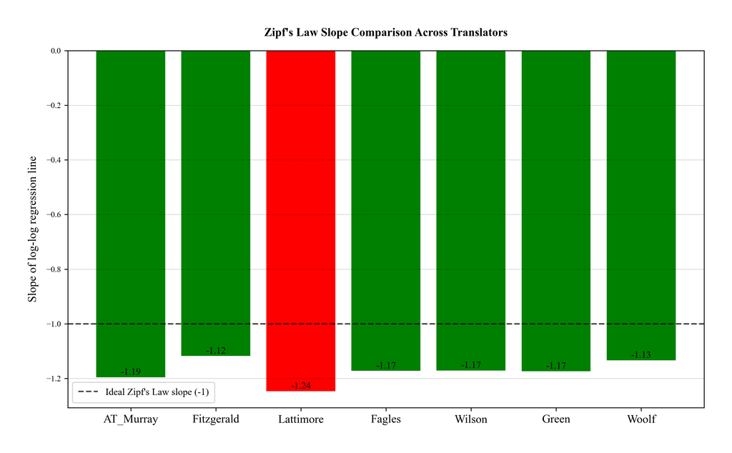

```
time: 436 ms (started: 2025-04-20 20:54:14 +02:00)
```

```python
# Bar chart to visualize slopes
plt.figure(figsize=(10, 6))
bars = plt.bar(translators, slopes)

# Color the bars based on whether they follow Zipf's Law
for i, follows in enumerate(follows_zipf):
    bars[i].set_color('green' if follows else 'red')

# Add a horizontal line at -1 (ideal Zipf's Law slope)
plt.axhline(y=-1, color='black', linestyle='--', alpha=0.7,
            label="Ideal Zipf's Law slope (-1)")

# Add value labels on top of bars
for i, bar in enumerate(bars):
    height = bar.get_height()
    plt.text(bar.get_x() + bar.get_width()/2., height,
            f'{slopes[i]:.2f}',
            ha='center', va='bottom' if height < 0 else 'top',
            rotation=0)

plt.title("Zipf's Law Slope Comparison Across Translators")
plt.ylabel("Slope of log-log regression line")
plt.legend()
plt.grid(axis='y', linestyle='--', alpha=0.7)
plt.tight_layout()
plt.savefig(output_path_plots + f"Comparison-{nb_id}.png")
plt.show()
```

```python
# Statistical comparison of slopes (using confidence intervals)
print("\nStatistical comparison of slopes:")
for i in range(len(translators)):
    for j in range(i+1, len(translators)):
        # Calculate standard error of the difference between slopes
        se_diff = np.sqrt(std_errs[i]**2 + std_errs[j]**2)

        # Calculate t-statistic
        t_stat = (slopes[i] - slopes[j]) / se_diff

        # Calculate degrees of freedom (approximation)
        d_freedom = len(df_word_freq_rank_dict[translators[i]]["rank"]) + len(df_word_freq_rank_dict[translators[j]]["rank"]) - 4

        # Calculate p-value
        from scipy.stats import t
        p_val = 2 * (1 - t.cdf(abs(t_stat), d_freedom))

        print(f"{translators[i]} vs {translators[j]}: Slope diff = {slopes[i]-slopes[j]:.3f}, p = {p_val:.4f}")
        if p_val < 0.05:
            print("   -> STATISTICALLY significant difference in slopes")
        else:
            print("   -> NOT statistically significant difference in slopes")
```

```
Statistical comparison of slopes:
AT_Murray vs Fitzgerald: Slope diff = -0.078, p = 0.0000
   -> STATISTICALLY significant difference in slopes
AT_Murray vs Lattimore: Slope diff = 0.051, p = 0.0000
   -> STATISTICALLY significant difference in slopes
AT_Murray vs Fagles: Slope diff = -0.024, p = 0.0000
   -> STATISTICALLY significant difference in slopes
AT_Murray vs Wilson: Slope diff = -0.025, p = 0.0000
   -> STATISTICALLY significant difference in slopes
AT_Murray vs Green: Slope diff = -0.022, p = 0.0000
   -> STATISTICALLY significant difference in slopes
AT_Murray vs Woolf: Slope diff = -0.062, p = 0.0000
   -> STATISTICALLY significant difference in slopes
Fitzgerald vs Lattimore: Slope diff = 0.129, p = 0.0000
   -> STATISTICALLY significant difference in slopes
Fitzgerald vs Fagles: Slope diff = 0.054, p = 0.0000
   -> STATISTICALLY significant difference in slopes
Fitzgerald vs Wilson: Slope diff = 0.053, p = 0.0000
   -> STATISTICALLY significant difference in slopes
Fitzgerald vs Green: Slope diff = 0.056, p = 0.0000
   -> STATISTICALLY significant difference in slopes
Fitzgerald vs Woolf: Slope diff = 0.016, p = 0.0000
   -> STATISTICALLY significant difference in slopes
Lattimore vs Fagles: Slope diff = -0.074, p = 0.0000
   -> STATISTICALLY significant difference in slopes
Lattimore vs Wilson: Slope diff = -0.075, p = 0.0000
   -> STATISTICALLY significant difference in slopes
Lattimore vs Green: Slope diff = -0.073, p = 0.0000
   -> STATISTICALLY significant difference in slopes
Lattimore vs Woolf: Slope diff = -0.113, p = 0.0000
   -> STATISTICALLY significant difference in slopes
Fagles vs Wilson: Slope diff = -0.001, p = 0.7930
   -> NOT statistically significant difference in slopes
Fagles vs Green: Slope diff = 0.001, p = 0.6789
   -> NOT statistically significant difference in slopes
Fagles vs Woolf: Slope diff = -0.039, p = 0.0000
   -> STATISTICALLY significant difference in slopes
Wilson vs Green: Slope diff = 0.002, p = 0.4734
   -> NOT statistically significant difference in slopes
Wilson vs Woolf: Slope diff = -0.038, p = 0.0000
   -> STATISTICALLY significant difference in slopes
Green vs Woolf: Slope diff = -0.040, p = 0.0000
   -> STATISTICALLY significant difference in slopes
time: 1.87 ms (started: 2025-04-20 20:54:14 +02:00)
```

This result add to the supposition that Fagles, Wilson and Green form a kind group.

```python
slopes = dict(zip(results_df['Translator'], results_df['Slope']))
slopes
```

```
{'AT_Murray': -1.1938277516804667,
 'Fitzgerald': -1.1157547600338376,
 'Lattimore': -1.2445595081994263,
 'Fagles': -1.1701011452556676,
 'Wilson': -1.169168818993014,
 'Green': -1.1715327968509333,
 'Woolf': -1.1315580364789302}
```

```
time: 2.35 ms (started: 2025-04-20 20:54:14 +02:00)
```

```python
#-----------------------------------------------------------------
# Perform pairwise t-tests for differences in slopes
#-----------------------------------------------------------------

from scipy.stats import ttest_ind

# Convert dictionary to a list of slopes
slope_values = list(slopes.values())

# Perform pairwise t-tests for differences in slopes
for i in range(len(slope_values)):
    for j in range(i+1, len(slope_values)):
        translator_1 = list(slopes.keys())[i]
        translator_2 = list(slopes.keys())[j]

        # Compare slopes for translator_1 and translator_2
        t_stat, p_value = ttest_ind([slope_values[i]], [slope_values[j]])

        # Interpretation
        print(f"Comparison: {translator_1} vs {translator_2}")
        print(f"T-statistic: {t_stat:.3f}, P-value: {p_value:.5f}")

        if p_value < 0.05:
            print(f"  -> There is a SIGNIFICANT difference in slopes between {translator_1} and {translator_2}.")
        else:
            print(f"  -> NOT significant difference in slopes between {translator_1} and {translator_2}.")
        print("-" * 50)
```

```
Comparison: AT_Murray vs Fitzgerald
T-statistic: nan, P-value: nan
  -> NOT significant difference in slopes between AT_Murray and Fitzgerald.
--------------------------------------------------
Comparison: AT_Murray vs Lattimore
T-statistic: nan, P-value: nan
  -> NOT significant difference in slopes between AT_Murray and Lattimore.
--------------------------------------------------
Comparison: AT_Murray vs Fagles
T-statistic: nan, P-value: nan
  -> NOT significant difference in slopes between AT_Murray and Fagles.
--------------------------------------------------
Comparison: AT_Murray vs Wilson
T-statistic: nan, P-value: nan
  -> NOT significant difference in slopes between AT_Murray and Wilson.
--------------------------------------------------
Comparison: AT_Murray vs Green
T-statistic: nan, P-value: nan
  -> NOT significant difference in slopes between AT_Murray and Green.
--------------------------------------------------
Comparison: AT_Murray vs Woolf
T-statistic: nan, P-value: nan
  -> NOT significant difference in slopes between AT_Murray and Woolf.
--------------------------------------------------
Comparison: Fitzgerald vs Lattimore
T-statistic: nan, P-value: nan
  -> NOT significant difference in slopes between Fitzgerald and Lattimore.
--------------------------------------------------
Comparison: Fitzgerald vs Fagles
T-statistic: nan, P-value: nan
  -> NOT significant difference in slopes between Fitzgerald and Fagles.
--------------------------------------------------
Comparison: Fitzgerald vs Wilson
T-statistic: nan, P-value: nan
  -> NOT significant difference in slopes between Fitzgerald and Wilson.
--------------------------------------------------
Comparison: Fitzgerald vs Green
T-statistic: nan, P-value: nan
  -> NOT significant difference in slopes between Fitzgerald and Green.
--------------------------------------------------
```

[output cut: 30 more lines]

```
  -> NOT significant difference in slopes between Fagles and Woolf.
--------------------------------------------------
Comparison: Wilson vs Green
T-statistic: nan, P-value: nan
  -> NOT significant difference in slopes between Wilson and Green.
--------------------------------------------------
Comparison: Wilson vs Woolf
T-statistic: nan, P-value: nan
  -> NOT significant difference in slopes between Wilson and Woolf.
--------------------------------------------------
Comparison: Green vs Woolf
T-statistic: nan, P-value: nan
  -> NOT significant difference in slopes between Green and Woolf.
--------------------------------------------------
time: 14.9 ms (started: 2025-04-20 20:54:14 +02:00)
```

```
ANOVA F-statistic: inf, P-value: 0.00000
There is a statistically significant difference in Zipf's Law slopes across translators.
```

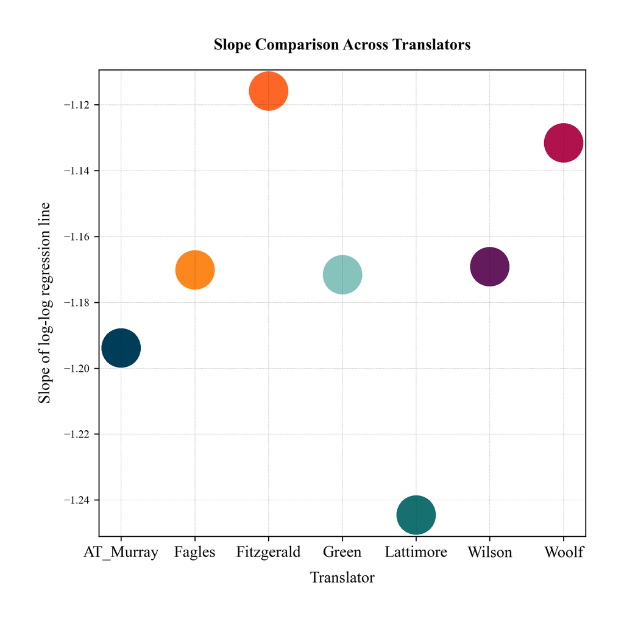

```
time: 39.4 s (started: 2025-04-20 20:54:14 +02:00)
```

```python
# ----------------------------------------------------------------------
# Zipf's Law Slope Comparison
# ----------------------------------------------------------------------

from scipy.stats import f_oneway

slopes_by_translator = {translator: [] for translator in df['translator'].unique()}

for index, row in df.iterrows():
    translator = row['translator']
    book_num = row['book_num']
    df_zipf = df_word_freq_rank_dict[translator]

    if 'book_num' not in df_zipf.columns:
        df_zipf['book_num'] = [book_num] * len(df_zipf)

    df_book = df_zipf[df_zipf['book_num'] == book_num]

    if not df_book.empty:
        log_rank = np.log(df_book["rank"] + 1)  # Add 1 to avoid log(0)
        log_freq = np.log(df_book["frequency"] + 1)  # Add 1 to avoid log(0)

        # Perform linear regression on the log-log space
        slope, intercept, r_value, p_value, std_err = linregress(log_rank, log_freq)
        slopes_by_translator[translator].append(slope)

slope_groups = [slopes_by_translator[translator] for translator in slopes_by_translator]
f_stat, p_value = f_oneway(*slope_groups)
print(f"ANOVA F-statistic: {f_stat:.3f}, P-value: {p_value:.5f}")
if p_value < 0.05:
    print("There is a statistically significant difference in Zipf's Law slopes across translators.")
else:
    print("No statistically significant difference in Zipf's Law slopes across translators.")

plt.figure(figsize=(6, 6))
for translator, slopes in slopes_by_translator.items():
    plt.scatter([translator] * len(slopes), slopes, label=translator,
            color=palette.get(translator, "gray"), s=800)

plt.title("Slope Comparison Across Translators")
plt.ylabel("Slope of log-log regression line")
plt.xlabel("Translator")
plt.grid(True, linestyle='--', alpha=0.4)
plt.xticks()
plt.tight_layout()
plt.savefig(output_path_plots + f"Translator_Slope_Box-{nb_id}.png")
plt.show()
```

```python
# ----------------------------------------------------------------------
# Bootstrapping the slope
# ----------------------------------------------------------------------
from scipy.stats import linregress

# Assuming you already have your DataFrame (df) and the 'zipf' columns are calculated

# Define a function for bootstrapping the slope
def bootstrap_slope(df, n_bootstrap=1000):
    slopes_bootstrap = []

    for _ in range(n_bootstrap):
        # Sample data with replacement
        bootstrap_sample = df.sample(n=len(df), replace=True)

        # Get the log-transformed rank and frequency
        log_rank = np.log(bootstrap_sample['rank'] + 1)  # Avoid log(0)
        log_freq = np.log(bootstrap_sample['frequency'] + 1)

        # Perform linear regression on the bootstrap sample
        slope, intercept, r_value, p_value, std_err = linregress(log_rank, log_freq)

        # Store the slope
        slopes_bootstrap.append(slope)

    # Convert to a numpy array for easier analysis
    slopes_bootstrap = np.array(slopes_bootstrap)

    # Calculate 95% confidence intervals
    lower_bound = np.percentile(slopes_bootstrap, 2.5)
    upper_bound = np.percentile(slopes_bootstrap, 97.5)

    # Return the distribution of slopes and the confidence intervals
    return slopes_bootstrap, lower_bound, upper_bound

# Now, let's apply the bootstrap for each author
bootstrap_results = {}
for translator in translators:
    df_translator = df_word_freq_rank_dict[translator]

    # Run the bootstrap procedure
    slopes_bootstrap, lower_bound, upper_bound = bootstrap_slope(df_translator, n_bootstrap=1000)

    # Store the results
    bootstrap_results[translator] = {
        'bootstrap_slopes': slopes_bootstrap,
        '95% CI Lower Bound': lower_bound,
        '95% CI Upper Bound': upper_bound
    }

# Print results
for translator, result in bootstrap_results.items():
    print(f"{translator}:")
    print(f"  95% CI for slope: ({result['95% CI Lower Bound']:.4f}, {result['95% CI Upper Bound']:.4f})")
    print(f"  Mean slope: {np.mean(result['bootstrap_slopes']):.4f}")
    print("-" * 50)
```

```
AT_Murray:
  95% CI for slope: (-1.2125, -1.1771)
  Mean slope: -1.1944
--------------------------------------------------
Fitzgerald:
  95% CI for slope: (-1.1285, -1.1016)
  Mean slope: -1.1156
--------------------------------------------------
Lattimore:
  95% CI for slope: (-1.2640, -1.2261)
  Mean slope: -1.2447
--------------------------------------------------
Fagles:
  95% CI for slope: (-1.1878, -1.1529)
  Mean slope: -1.1704
--------------------------------------------------
Wilson:
  95% CI for slope: (-1.1872, -1.1502)
  Mean slope: -1.1695
--------------------------------------------------
Green:
  95% CI for slope: (-1.1890, -1.1561)
  Mean slope: -1.1720
--------------------------------------------------
Woolf:
  95% CI for slope: (-1.1440, -1.1189)
  Mean slope: -1.1318
--------------------------------------------------
time: 3.4 s (started: 2025-04-20 20:54:53 +02:00)
```